# Project_Scoring_Model_2026

## DEVELOPING A SCORING MODEL for “Lend to Spend” that lends to people with little or no credit history.

#### Before approving a loan, the company calculates the probability that the borrower will default. It is therefore looking for a scoring algorithm that will enable it to decide whether or not to lend to a given borrower.

## REQUIREMENT:

### Create at least three new variables based on the existing variables you think are relevant for improving the model’s predictive power.

```python
##importing all necessary modules
import numpy as np
import pandas as pd
import pylab as pl
import matplotlib.pyplot as plt
import plotly.express as px
from sklearn.model_selection import train_test_split
from sklearn.ensemble import RandomForestClassifier
from sklearn.metrics import accuracy_score
from sklearn.metrics import f1_score, confusion_matrix, roc_curve, auc
from sklearn.preprocessing import label_binarize
from itertools import cycle
from sklearn.preprocessing import StandardScaler
from sklearn.linear_model import LogisticRegression
from sklearn.metrics import classification_report, confusion_matrix
import seaborn as sns
sns.set()
```

```python
## This is a supervised learning,classification model as the output will be a a category
```

## Creating functions to be used

```python
def plot_bar(dataframe,column_name):
    pandas_df= dataframe
    plt.figure(figsize=(10,10))
    plt.bar(pandas_df[column_name].value_counts().index,pandas_df[column_name].value_counts())
    plt.title(f'Distribution on {column_name}column')
    plt.xlabel(column_name)
    plt.ylabel('Count')
    plt.show()
```

```python
def analysis(dataframe):
    df=dataframe
    Shape_df=df.shape
    list_of_columns=df.columns.to_list()
    percent_missing = df.isnull().sum().sort_values(ascending=False) * 100 / len(df)
    duplicate_counts = {col: df[col].duplicated().sum() for col in df.columns}
    print('Shape: ')
    print(Shape_df)
    print('List of columns: ')
    print(list_of_columns)
```

```python
def percent_nulls(dataframe):
    df=dataframe
    percent_missing = df.isnull().sum().sort_values(ascending=False) * 100 / len(df)
    print('Percentage of nulls: ')
    print(percent_missing)
```

```python
def outliers_chk(dataframe):
    df=dataframe
    for col in df.columns:
        if df[col].dtype != 'object'and df[col].dtype != 'str'and df[col].dtype != 'bool' and dataframe[col].dtype !='category':
            if col !='SK_ID_CURR'and col != 'TARGET' and col !='SK_ID_BUREAU' and col != 'SK_ID_PREV':
                print(f'Outlier in {col} column')
                sns.boxplot(df[col])
                plt.show()
```

## Exploratory Data analysis for all the files provided.

### EDA FOR BUREAU.CSV

## bureau.csv

#### All client's previous credits provided by other financial institutions that were reported to Credit Bureau (for clients who have a loan in our sample).

#### For every loan in our sample, there are as many rows as number of credits the client had in Credit Bureau before the application date.

```python
## Import file
df_bureau = pd.read_csv("BUREAU.csv")
```

```python
df_bureau.shape
```

```
(1716428, 17)
```

```python
df_bureau.head()
```

|  | SK_ID_CURR | SK_ID_BUREAU | CREDIT_ACTIVE | CREDIT_CURRENCY | DAYS_CREDIT | CREDIT_DAY_OVERDUE | DAYS_CREDIT_ENDDATE | DAYS_ENDDATE_FACT | AMT_CREDIT_MAX_OVERDUE | CNT_CREDIT_PROLONG | AMT_CREDIT_SUM | AMT_CREDIT_SUM_DEBT | AMT_CREDIT_SUM_LIMIT | AMT_CREDIT_SUM_OVERDUE | CREDIT_TYPE | DAYS_CREDIT_UPDATE | AMT_ANNUITY |
| --- | --- | --- | --- | --- | --- | --- | --- | --- | --- | --- | --- | --- | --- | --- | --- | --- | --- |
| 0 | 215354 | 5714462 | Closed | currency 1 | -497 | 0 | -153.0 | -153.0 | NaN | 0 | 91323.0 | 0.0 | NaN | 0.0 | Consumer credit | -131 | NaN |
| 1 | 215354 | 5714463 | Active | currency 1 | -208 | 0 | 1075.0 | NaN | NaN | 0 | 225000.0 | 171342.0 | NaN | 0.0 | Credit card | -20 | NaN |
| 2 | 215354 | 5714464 | Active | currency 1 | -203 | 0 | 528.0 | NaN | NaN | 0 | 464323.5 | NaN | NaN | 0.0 | Consumer credit | -16 | NaN |
| 3 | 215354 | 5714465 | Active | currency 1 | -203 | 0 | NaN | NaN | NaN | 0 | 90000.0 | NaN | NaN | 0.0 | Credit card | -16 | NaN |
| 4 | 215354 | 5714466 | Active | currency 1 | -629 | 0 | 1197.0 | NaN | 77674.5 | 0 | 2700000.0 | NaN | NaN | 0.0 | Consumer credit | -21 | NaN |

```python
analysis(df_bureau)
```

```
Shape:
(1716428, 17)
List of columns:
['SK_ID_CURR', 'SK_ID_BUREAU', 'CREDIT_ACTIVE', 'CREDIT_CURRENCY', 'DAYS_CREDIT', 'CREDIT_DAY_OVERDUE', 'DAYS_CREDIT_ENDDATE', 'DAYS_ENDDATE_FACT', 'AMT_CREDIT_MAX_OVERDUE', 'CNT_CREDIT_PROLONG', 'AMT_CREDIT_SUM', 'AMT_CREDIT_SUM_DEBT', 'AMT_CREDIT_SUM_LIMIT', 'AMT_CREDIT_SUM_OVERDUE', 'CREDIT_TYPE'…
```

```python
percent_nulls(df_bureau)
```

```
Percentage of nulls:
AMT_ANNUITY               71.473490
AMT_CREDIT_MAX_OVERDUE    65.513264
DAYS_ENDDATE_FACT         36.916958
AMT_CREDIT_SUM_LIMIT      34.477415
AMT_CREDIT_SUM_DEBT       15.011932
DAYS_CREDIT_ENDDATE        6.149573
AMT_CREDIT_SUM             0.000757
CREDIT_ACTIVE              0.000000
CREDIT_CURRENCY            0.000000
DAYS_CREDIT                0.000000
CREDIT_DAY_OVERDUE         0.000000
SK_ID_BUREAU               0.000000
CNT_CREDIT_PROLONG         0.000000
AMT_CREDIT_SUM_OVERDUE     0.000000
CREDIT_TYPE                0.000000
DAYS_CREDIT_UPDATE         0.000000
SK_ID_CURR                 0.000000
dtype: float64
```

```python
df_bureau_reqd=df_bureau.copy()
```

```python
df_bureau_reqd= df_bureau_reqd[['SK_ID_CURR', 'SK_ID_BUREAU', 'CREDIT_ACTIVE','DAYS_CREDIT_ENDDATE', 'CREDIT_DAY_OVERDUE',
       'AMT_CREDIT_SUM', 'AMT_CREDIT_SUM_DEBT', 'AMT_CREDIT_SUM_LIMIT',
       'CREDIT_TYPE', 'DAYS_CREDIT_UPDATE']]
```

```python
df_bureau_reqd.nunique()  ## checking unique values in each column
```

```
SK_ID_CURR               305811
SK_ID_BUREAU            1716428
CREDIT_ACTIVE                 4
DAYS_CREDIT_ENDDATE       14096
CREDIT_DAY_OVERDUE          942
AMT_CREDIT_SUM           236708
AMT_CREDIT_SUM_DEBT      226537
AMT_CREDIT_SUM_LIMIT      51726
CREDIT_TYPE                  15
DAYS_CREDIT_UPDATE         2982
dtype: int64
```

```python
df_bureau_reqd.head()
```

|  | SK_ID_CURR | SK_ID_BUREAU | CREDIT_ACTIVE | DAYS_CREDIT_ENDDATE | CREDIT_DAY_OVERDUE | AMT_CREDIT_SUM | AMT_CREDIT_SUM_DEBT | AMT_CREDIT_SUM_LIMIT | CREDIT_TYPE | DAYS_CREDIT_UPDATE |
| --- | --- | --- | --- | --- | --- | --- | --- | --- | --- | --- |
| 0 | 215354 | 5714462 | Closed | -153.0 | 0 | 91323.0 | 0.0 | NaN | Consumer credit | -131 |
| 1 | 215354 | 5714463 | Active | 1075.0 | 0 | 225000.0 | 171342.0 | NaN | Credit card | -20 |
| 2 | 215354 | 5714464 | Active | 528.0 | 0 | 464323.5 | NaN | NaN | Consumer credit | -16 |
| 3 | 215354 | 5714465 | Active | NaN | 0 | 90000.0 | NaN | NaN | Credit card | -16 |
| 4 | 215354 | 5714466 | Active | 1197.0 | 0 | 2700000.0 | NaN | NaN | Consumer credit | -21 |

```python
df_bureau_reqd['CREDIT_TYPE'].values
```

```
array(['Consumer credit', 'Credit card', 'Consumer credit', ...,
       'Consumer credit', 'Consumer credit', 'Microloan'], dtype=object)
```

```python
percent_nulls(df_bureau_reqd)
```

```
Percentage of nulls:
AMT_CREDIT_SUM_LIMIT    34.477415
AMT_CREDIT_SUM_DEBT     15.011932
DAYS_CREDIT_ENDDATE      6.149573
AMT_CREDIT_SUM           0.000757
SK_ID_CURR               0.000000
SK_ID_BUREAU             0.000000
CREDIT_ACTIVE            0.000000
CREDIT_DAY_OVERDUE       0.000000
CREDIT_TYPE              0.000000
DAYS_CREDIT_UPDATE       0.000000
dtype: float64
```

#### The columns that can be used are :

#### SK_ID_CURR

#### SK_ID_BUREAU

#### CREDIT_ACTIVE

#### CREDIT_DAY_OVERDUE

#### CREDIT_TYPE

#### DAYS_CREDIT_UPDATE

### 'SK_ID_CURR', 'SK_ID_BUREAU',CREDIT_ACTIVE, CREDIT_DAY_OVERDUE,CREDIT_TYPE are free from nulls and can be used

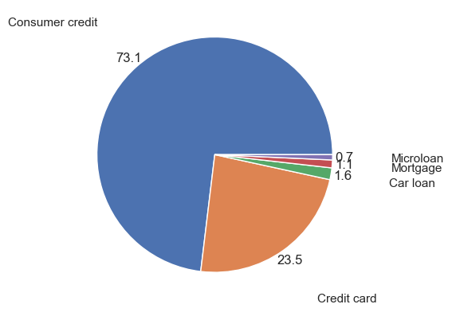

```python
df_bureau_reqd["CREDIT_TYPE"].value_counts().head(5).plot(kind='pie',autopct='%.1f',ylabel='', pctdistance=1.1, labeldistance=1.5)
```

```python
df_bureau_reqd["CREDIT_ACTIVE"].value_counts()
```

```
CREDIT_ACTIVE
Closed      1079273
Active       630607
Sold           6527
Bad debt         21
Name: count, dtype: int64
```

```python
def plot_bar(dataframe,column_name):
    pandas_df= dataframe
    plt.figure(figsize=(8,5))
    plt.bar(pandas_df[column_name].value_counts().index,pandas_df[column_name].value_counts())
    plt.title(f'Distribution on {column_name}column')
    plt.xlabel(column_name)
    plt.ylabel('Count')
    plt.show()
```

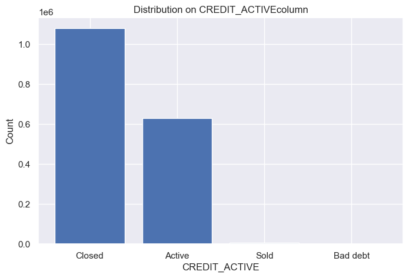

```python
plot_bar(df_bureau_reqd,'CREDIT_ACTIVE')
```

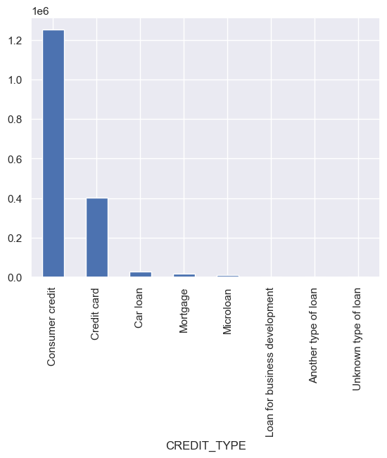

```python
df_bureau_reqd["CREDIT_TYPE"].value_counts().head(8).plot(kind ='bar')
```

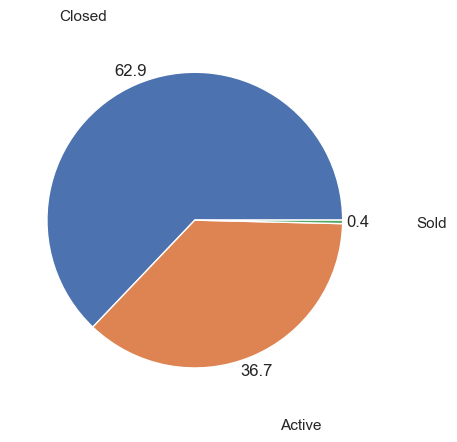

```python
df_bureau_reqd["CREDIT_ACTIVE"].value_counts().head(3).plot(kind='pie',autopct='%.1f',ylabel='', pctdistance=1.1, labeldistance=1.5)
```

#### Observation: CREDIT ACTIVE STATUS (CLOSED,ACTIVE,SOLD,BAD DEBT)....

#### FOR CREDIT_ACTIVE STATUS as CLOSED>>>the person is eligible for new credit

#### FOR CREDIT_ACTIVE STATUS as ACTIVE>>> check CREDIT_DAY_OVERDUE (condition of one week,7 days can be used)

## FILE : POS_CASH_BALANCE (Data Exploration)

## POS_CASH_balance.csv

#### Monthly balance snapshots of previous POS (point of sales) and cash loans that the applicant had with Home Credit.

#### This table has one row for each month of history of every previous credit in Home Credit (consumer credit and cash loans) related to loans in our sample – i.e. the table has (#loans in sample * # of relative previous credits * # of months in which we have some history observable for the previous credits) rows.

```python
df_pos_cash_balance = pd.read_csv("POS_CASH_balance.csv")
```

```python
df_pos_cash_balance.head()
```

|  | SK_ID_PREV | SK_ID_CURR | MONTHS_BALANCE | CNT_INSTALMENT | CNT_INSTALMENT_FUTURE | NAME_CONTRACT_STATUS | SK_DPD | SK_DPD_DEF |
| --- | --- | --- | --- | --- | --- | --- | --- | --- |
| 0 | 1803195 | 182943 | -31 | 48.0 | 45.0 | Active | 0 | 0 |
| 1 | 1715348 | 367990 | -33 | 36.0 | 35.0 | Active | 0 | 0 |
| 2 | 1784872 | 397406 | -32 | 12.0 | 9.0 | Active | 0 | 0 |
| 3 | 1903291 | 269225 | -35 | 48.0 | 42.0 | Active | 0 | 0 |
| 4 | 2341044 | 334279 | -35 | 36.0 | 35.0 | Active | 0 | 0 |

```python
analysis(df_pos_cash_balance)
```

```
Shape:
(10001358, 8)
List of columns:
['SK_ID_PREV', 'SK_ID_CURR', 'MONTHS_BALANCE', 'CNT_INSTALMENT', 'CNT_INSTALMENT_FUTURE', 'NAME_CONTRACT_STATUS', 'SK_DPD', 'SK_DPD_DEF']
```

```python
percent_nulls(df_pos_cash_balance)
```

```
Percentage of nulls:
CNT_INSTALMENT_FUTURE    0.260835
CNT_INSTALMENT           0.260675
SK_ID_PREV               0.000000
SK_ID_CURR               0.000000
MONTHS_BALANCE           0.000000
NAME_CONTRACT_STATUS     0.000000
SK_DPD                   0.000000
SK_DPD_DEF               0.000000
dtype: float64
```

#### POS_CASH_balance.csv is the file with count of installments and future installments /contract_status

#### We will use only contract_status and months_balance (to see how long the contract will be active)

```python
df_pos_cash_balance_reqd=df_pos_cash_balance.copy()
```

```python
df_pos_cash_balance_reqd=df_pos_cash_balance_reqd[['SK_ID_PREV','SK_ID_CURR','MONTHS_BALANCE','NAME_CONTRACT_STATUS']]
```

### There are no nulls in this chosen dataset

```python
df_pos_cash_balance_reqd.shape
```

```
(10001358, 4)
```

```python
df_pos_cash_balance_reqd.head(10)
```

|  | SK_ID_PREV | SK_ID_CURR | MONTHS_BALANCE | NAME_CONTRACT_STATUS |
| --- | --- | --- | --- | --- |
| 0 | 1803195 | 182943 | -31 | Active |
| 1 | 1715348 | 367990 | -33 | Active |
| 2 | 1784872 | 397406 | -32 | Active |
| 3 | 1903291 | 269225 | -35 | Active |
| 4 | 2341044 | 334279 | -35 | Active |
| 5 | 2207092 | 342166 | -32 | Active |
| 6 | 1110516 | 204376 | -38 | Active |
| 7 | 1387235 | 153211 | -35 | Active |
| 8 | 1220500 | 112740 | -31 | Active |
| 9 | 2371489 | 274851 | -32 | Active |

```python
df_pos_cash_balance_reqd['NAME_CONTRACT_STATUS_N']=df_pos_cash_balance_reqd['NAME_CONTRACT_STATUS'].replace({'Completed': 0, 'Active': 1, 'Signed':2})
```

```python
df_pos_cash_balance_reqd.columns
```

```
Index(['SK_ID_PREV', 'SK_ID_CURR', 'MONTHS_BALANCE', 'NAME_CONTRACT_STATUS',
       'NAME_CONTRACT_STATUS_N'],
      dtype='object')
```

```python
##plot_bar(df_pos_cash_balance_reqd,'NAME_CONTRACT_STATUS')
```

## FILE:credit_card_balance.csv

### DATA EXPLORATION "credit_card_balance.csv"

## credit_card_balance.csv

### Monthly balance snapshots of previous credit cards that the applicant has with Home Credit.

### This table has one row for each month of history of every previous credit in Home Credit (consumer credit and cash loans) related to loans in our sample – i.e. the table has (#loans in sample * # of relative previous credit cards * # of months where we have some history observable for the previous credit card) rows.

```python
df_credit_card = pd.read_csv("credit_card_balance.csv")
```

```python
analysis(df_credit_card)
```

```
Shape:
(3840312, 23)
List of columns:
['SK_ID_PREV', 'SK_ID_CURR', 'MONTHS_BALANCE', 'AMT_BALANCE', 'AMT_CREDIT_LIMIT_ACTUAL', 'AMT_DRAWINGS_ATM_CURRENT', 'AMT_DRAWINGS_CURRENT', 'AMT_DRAWINGS_OTHER_CURRENT', 'AMT_DRAWINGS_POS_CURRENT', 'AMT_INST_MIN_REGULARITY', 'AMT_PAYMENT_CURRENT', 'AMT_PAYMENT_TOTAL_CURRENT', 'AMT_RECEIVABLE_PRINCI…
```

```python
df_credit_card.head()
```

|  | SK_ID_PREV | SK_ID_CURR | MONTHS_BALANCE | AMT_BALANCE | AMT_CREDIT_LIMIT_ACTUAL | AMT_DRAWINGS_ATM_CURRENT | AMT_DRAWINGS_CURRENT | AMT_DRAWINGS_OTHER_CURRENT | AMT_DRAWINGS_POS_CURRENT | AMT_INST_MIN_REGULARITY | ... | AMT_RECIVABLE | AMT_TOTAL_RECEIVABLE | CNT_DRAWINGS_ATM_CURRENT | CNT_DRAWINGS_CURRENT | CNT_DRAWINGS_OTHER_CURRENT | CNT_DRAWINGS_POS_CURRENT | CNT_INSTALMENT_MATURE_CUM | NAME_CONTRACT_STATUS | SK_DPD | SK_DPD_DEF |
| --- | --- | --- | --- | --- | --- | --- | --- | --- | --- | --- | --- | --- | --- | --- | --- | --- | --- | --- | --- | --- | --- |
| 0 | 2562384 | 378907 | -6 | 56.970 | 135000 | 0.0 | 877.5 | 0.0 | 877.5 | 1700.325 | ... | 0.000 | 0.000 | 0.0 | 1 | 0.0 | 1.0 | 35.0 | Active | 0 | 0 |
| 1 | 2582071 | 363914 | -1 | 63975.555 | 45000 | 2250.0 | 2250.0 | 0.0 | 0.0 | 2250.000 | ... | 64875.555 | 64875.555 | 1.0 | 1 | 0.0 | 0.0 | 69.0 | Active | 0 | 0 |
| 2 | 1740877 | 371185 | -7 | 31815.225 | 450000 | 0.0 | 0.0 | 0.0 | 0.0 | 2250.000 | ... | 31460.085 | 31460.085 | 0.0 | 0 | 0.0 | 0.0 | 30.0 | Active | 0 | 0 |
| 3 | 1389973 | 337855 | -4 | 236572.110 | 225000 | 2250.0 | 2250.0 | 0.0 | 0.0 | 11795.760 | ... | 233048.970 | 233048.970 | 1.0 | 1 | 0.0 | 0.0 | 10.0 | Active | 0 | 0 |
| 4 | 1891521 | 126868 | -1 | 453919.455 | 450000 | 0.0 | 11547.0 | 0.0 | 11547.0 | 22924.890 | ... | 453919.455 | 453919.455 | 0.0 | 1 | 0.0 | 1.0 | 101.0 | Active | 0 | 0 |

5 rows × 23 columns

#### This file gives us the credit card history and ATM withdrawals

```python
df_credit_card_reqd=df_credit_card.copy()
```

```python
df_credit_card_reqd=df_credit_card_reqd[['AMT_CREDIT_LIMIT_ACTUAL','AMT_PAYMENT_TOTAL_CURRENT','AMT_TOTAL_RECEIVABLE','NAME_CONTRACT_STATUS']]
```

### AMT_CREDIT_LIMIT_ACTUAL:

### Credit card limit during the month of the previous credit

### AMT_PAYMENT_TOTAL_CURRENT:

### How much did the client pay during the month in total on the previous credit

### AMT_TOTAL_RECEIVABLE:

### Total amount receivable on the previous credit

### NAME_CONTRACT_STATUS:

### Contract status during the month

```python
df_credit_card_reqd.head(5)
```

|  | AMT_CREDIT_LIMIT_ACTUAL | AMT_PAYMENT_TOTAL_CURRENT | AMT_TOTAL_RECEIVABLE | NAME_CONTRACT_STATUS |
| --- | --- | --- | --- | --- |
| 0 | 135000 | 1800.0 | 0.000 | Active |
| 1 | 45000 | 2250.0 | 64875.555 | Active |
| 2 | 450000 | 2250.0 | 31460.085 | Active |
| 3 | 225000 | 11925.0 | 233048.970 | Active |
| 4 | 450000 | 27000.0 | 453919.455 | Active |

```python
percent_nulls(df_credit_card_reqd)
```

```
Percentage of nulls:
AMT_CREDIT_LIMIT_ACTUAL      0.0
AMT_PAYMENT_TOTAL_CURRENT    0.0
AMT_TOTAL_RECEIVABLE         0.0
NAME_CONTRACT_STATUS         0.0
dtype: float64
```

### File: installments_payments.csv,data exploration of file

### EDA of installments_payments.csv

#### Repayment history for the previously disbursed credits in Home Credit related to the loans in our sample.

#### There is

#### a) one row for every payment that was made plus

#### b) one row each for missed payment.One row is equivalent to one payment of one installment OR one installment corresponding to one payment of one previous Home Credit credit related to loans in our sample.

```python
df_installments_payments = pd.read_csv("installments_payments.csv")
```

```python
df_installments_payments.head(5)
```

|  | SK_ID_PREV | SK_ID_CURR | NUM_INSTALMENT_VERSION | NUM_INSTALMENT_NUMBER | DAYS_INSTALMENT | DAYS_ENTRY_PAYMENT | AMT_INSTALMENT | AMT_PAYMENT |
| --- | --- | --- | --- | --- | --- | --- | --- | --- |
| 0 | 1054186 | 161674 | 1.0 | 6 | -1180.0 | -1187.0 | 6948.360 | 6948.360 |
| 1 | 1330831 | 151639 | 0.0 | 34 | -2156.0 | -2156.0 | 1716.525 | 1716.525 |
| 2 | 2085231 | 193053 | 2.0 | 1 | -63.0 | -63.0 | 25425.000 | 25425.000 |
| 3 | 2452527 | 199697 | 1.0 | 3 | -2418.0 | -2426.0 | 24350.130 | 24350.130 |
| 4 | 2714724 | 167756 | 1.0 | 2 | -1383.0 | -1366.0 | 2165.040 | 2160.585 |

```python
analysis(df_installments_payments)
```

```
Shape:
(13605401, 8)
List of columns:
['SK_ID_PREV', 'SK_ID_CURR', 'NUM_INSTALMENT_VERSION', 'NUM_INSTALMENT_NUMBER', 'DAYS_INSTALMENT', 'DAYS_ENTRY_PAYMENT', 'AMT_INSTALMENT', 'AMT_PAYMENT']
```

```python
percent_nulls(df_installments_payments)
```

```
Percentage of nulls:
DAYS_ENTRY_PAYMENT        0.021352
AMT_PAYMENT               0.021352
SK_ID_PREV                0.000000
SK_ID_CURR                0.000000
NUM_INSTALMENT_VERSION    0.000000
NUM_INSTALMENT_NUMBER     0.000000
DAYS_INSTALMENT           0.000000
AMT_INSTALMENT            0.000000
dtype: float64
```

### File:previous_application.csv

### Data Exploration of 'previous_application.csv'

## previous_application.csv

#### All previous applications for Home Credit loans of clients who have loans in our sample.

#### There is one row for each previous application related to loans in our data sample.

```python
df_previous_application = pd.read_csv("previous_application.csv")
```

```python
analysis(df_previous_application)
```

```
Shape:
(1670214, 37)
List of columns:
['SK_ID_PREV', 'SK_ID_CURR', 'NAME_CONTRACT_TYPE', 'AMT_ANNUITY', 'AMT_APPLICATION', 'AMT_CREDIT', 'AMT_DOWN_PAYMENT', 'AMT_GOODS_PRICE', 'WEEKDAY_APPR_PROCESS_START', 'HOUR_APPR_PROCESS_START', 'FLAG_LAST_APPL_PER_CONTRACT', 'NFLAG_LAST_APPL_IN_DAY', 'RATE_DOWN_PAYMENT', 'RATE_INTEREST_PRIMARY', 'R…
```

```python
percent_nulls(df_previous_application)
```

```
Percentage of nulls:
RATE_INTEREST_PRIVILEGED       99.643698
RATE_INTEREST_PRIMARY          99.643698
AMT_DOWN_PAYMENT               53.636480
RATE_DOWN_PAYMENT              53.636480
NAME_TYPE_SUITE                49.119754
NFLAG_INSURED_ON_APPROVAL      40.298129
DAYS_TERMINATION               40.298129
DAYS_LAST_DUE                  40.298129
DAYS_LAST_DUE_1ST_VERSION      40.298129
DAYS_FIRST_DUE                 40.298129
DAYS_FIRST_DRAWING             40.298129
AMT_GOODS_PRICE                23.081773
AMT_ANNUITY                    22.286665
CNT_PAYMENT                    22.286366
PRODUCT_COMBINATION             0.020716
AMT_CREDIT                      0.000060
NAME_YIELD_GROUP                0.000000
NAME_PORTFOLIO                  0.000000
NAME_SELLER_INDUSTRY            0.000000
SELLERPLACE_AREA                0.000000
CHANNEL_TYPE                    0.000000
NAME_PRODUCT_TYPE               0.000000
SK_ID_PREV                      0.000000
NAME_GOODS_CATEGORY             0.000000
NAME_CLIENT_TYPE                0.000000
CODE_REJECT_REASON              0.000000
SK_ID_CURR                      0.000000
DAYS_DECISION                   0.000000
NAME_CONTRACT_STATUS            0.000000
NAME_CASH_LOAN_PURPOSE          0.000000
NFLAG_LAST_APPL_IN_DAY          0.000000
FLAG_LAST_APPL_PER_CONTRACT     0.000000
HOUR_APPR_PROCESS_START         0.000000
WEEKDAY_APPR_PROCESS_START      0.000000
AMT_APPLICATION                 0.000000
NAME_CONTRACT_TYPE              0.000000
NAME_PAYMENT_TYPE               0.000000
dtype: float64
```

## SK_ID_PREV :ID of previous credit in Home Credit related to loan in our sample.

#### (One loan in our sample can have 0,1,2 or more previous loans in Home Credit)

## SK_ID_CURR:ID of loan in our sample

```python
df_previous_application.head()
```

|  | SK_ID_PREV | SK_ID_CURR | NAME_CONTRACT_TYPE | AMT_ANNUITY | AMT_APPLICATION | AMT_CREDIT | AMT_DOWN_PAYMENT | AMT_GOODS_PRICE | WEEKDAY_APPR_PROCESS_START | HOUR_APPR_PROCESS_START | ... | NAME_SELLER_INDUSTRY | CNT_PAYMENT | NAME_YIELD_GROUP | PRODUCT_COMBINATION | DAYS_FIRST_DRAWING | DAYS_FIRST_DUE | DAYS_LAST_DUE_1ST_VERSION | DAYS_LAST_DUE | DAYS_TERMINATION | NFLAG_INSURED_ON_APPROVAL |
| --- | --- | --- | --- | --- | --- | --- | --- | --- | --- | --- | --- | --- | --- | --- | --- | --- | --- | --- | --- | --- | --- |
| 0 | 2030495 | 271877 | Consumer loans | 1730.430 | 17145.0 | 17145.0 | 0.0 | 17145.0 | SATURDAY | 15 | ... | Connectivity | 12.0 | middle | POS mobile with interest | 365243.0 | -42.0 | 300.0 | -42.0 | -37.0 | 0.0 |
| 1 | 2802425 | 108129 | Cash loans | 25188.615 | 607500.0 | 679671.0 | NaN | 607500.0 | THURSDAY | 11 | ... | XNA | 36.0 | low_action | Cash X-Sell: low | 365243.0 | -134.0 | 916.0 | 365243.0 | 365243.0 | 1.0 |
| 2 | 2523466 | 122040 | Cash loans | 15060.735 | 112500.0 | 136444.5 | NaN | 112500.0 | TUESDAY | 11 | ... | XNA | 12.0 | high | Cash X-Sell: high | 365243.0 | -271.0 | 59.0 | 365243.0 | 365243.0 | 1.0 |
| 3 | 2819243 | 176158 | Cash loans | 47041.335 | 450000.0 | 470790.0 | NaN | 450000.0 | MONDAY | 7 | ... | XNA | 12.0 | middle | Cash X-Sell: middle | 365243.0 | -482.0 | -152.0 | -182.0 | -177.0 | 1.0 |
| 4 | 1784265 | 202054 | Cash loans | 31924.395 | 337500.0 | 404055.0 | NaN | 337500.0 | THURSDAY | 9 | ... | XNA | 24.0 | high | Cash Street: high | NaN | NaN | NaN | NaN | NaN | NaN |

5 rows × 37 columns

### The purpose of this file is to know the status of any previous loan application and the status of approval/rejection

### The columns that we require from this file are :

#### AMT_CREDIT, NAME_CONTRACT_TYPE , NAME_PAYMENT_TYPE, NAME_CONTRACT_STATUS

### AMT_CREDIT :

#### Final credit amount on the previous application. This differs from AMT_APPLICATION,

#### in a way that the AMT_APPLICATION is the amount for which the client initially applied for,

#### but during our approval process he could have received different amount - AMT_CREDIT

### NAME_CONTRACT_TYPE:

#### Contract product_type (Cash loan, consumer loan [POS] ,...) of the previous application

### NAME_PAYMENT_TYPE:

#### Payment method that client chose to pay for the previous application

### NAME_CONTRACT_STATUS:

#### Contract status (approved, cancelled, ...) of previous application

### CODE_REJECT_REASON:

#### Why was the previous application rejected

```python
df_previous_application_reqd= df_previous_application[['SK_ID_PREV','SK_ID_CURR','AMT_CREDIT','NAME_CONTRACT_TYPE','NAME_PAYMENT_TYPE','NAME_CONTRACT_STATUS','CODE_REJECT_REASON']]
```

```python
analysis(df_previous_application)
```

```
Shape:
(1670214, 37)
List of columns:
['SK_ID_PREV', 'SK_ID_CURR', 'NAME_CONTRACT_TYPE', 'AMT_ANNUITY', 'AMT_APPLICATION', 'AMT_CREDIT', 'AMT_DOWN_PAYMENT', 'AMT_GOODS_PRICE', 'WEEKDAY_APPR_PROCESS_START', 'HOUR_APPR_PROCESS_START', 'FLAG_LAST_APPL_PER_CONTRACT', 'NFLAG_LAST_APPL_IN_DAY', 'RATE_DOWN_PAYMENT', 'RATE_INTEREST_PRIMARY', 'R…
```

```python
df_previous_application_reqd.head()
```

|  | SK_ID_PREV | SK_ID_CURR | AMT_CREDIT | NAME_CONTRACT_TYPE | NAME_PAYMENT_TYPE | NAME_CONTRACT_STATUS | CODE_REJECT_REASON |
| --- | --- | --- | --- | --- | --- | --- | --- |
| 0 | 2030495 | 271877 | 17145.0 | Consumer loans | Cash through the bank | Approved | XAP |
| 1 | 2802425 | 108129 | 679671.0 | Cash loans | XNA | Approved | XAP |
| 2 | 2523466 | 122040 | 136444.5 | Cash loans | Cash through the bank | Approved | XAP |
| 3 | 2819243 | 176158 | 470790.0 | Cash loans | Cash through the bank | Approved | XAP |
| 4 | 1784265 | 202054 | 404055.0 | Cash loans | Cash through the bank | Refused | HC |

### Columns that we chose from all the above files

```python
potential_features=['SK_ID_CURR', 'SK_ID_BUREAU','CREDIT_ACTIVE', 'CREDIT_DAY_OVERDUE','CREDIT_TYPE','SK_ID_PREV',
                     'MONTHS_BALANCE', 'NAME_CONTRACT_STATUS', 'NAME_CONTRACT_STATUS_N'
                   'AMT_CREDIT_LIMIT_ACTUAL','AMT_PAYMENT_TOTAL_CURRENT','AMT_TOTAL_RECEIVABLE',
                    'NAME_CONTRACT_STATUS','NUM_INSTALMENT_VERSION','NUM_INSTALMENT_NUMBER',
                    'DAYS_INSTALMENT', 'DAYS_ENTRY_PAYMENT',
                    'AMT_INSTALMENT', 'AMT_PAYMENT']
```

```python
df_application_train = pd.read_csv("application_train.csv")
```

```python
analysis(df_application_train)
```

```
Shape:
(307511, 122)
List of columns:
['SK_ID_CURR', 'TARGET', 'NAME_CONTRACT_TYPE', 'CODE_GENDER', 'FLAG_OWN_CAR', 'FLAG_OWN_REALTY', 'CNT_CHILDREN', 'AMT_INCOME_TOTAL', 'AMT_CREDIT', 'AMT_ANNUITY', 'AMT_GOODS_PRICE', 'NAME_TYPE_SUITE', 'NAME_INCOME_TYPE', 'NAME_EDUCATION_TYPE', 'NAME_FAMILY_STATUS', 'NAME_HOUSING_TYPE', 'REGION_POPULA…
```

```python
application_features=list(df_application_train.columns)
```

## Comparing features from both the files

```python
result = set(potential_features) & set(application_features)
```

```python
print(list(result))
```

```
['SK_ID_CURR']
```

## The only column that connects all the tables is SK_ID_CURR while application_train.csv contains all the data required to train the model. (source:kaggle)

```python
### Checking shape of test file
```

```python
df_application_test = pd.read_csv("application_test.csv")
```

```python
df_application_test.shape
```

```
(48744, 121)
```

## Check df_application_train

```python
analysis(df_application_train) ### Check shape of test file and the list of columns
```

```
Shape:
(307511, 122)
List of columns:
['SK_ID_CURR', 'TARGET', 'NAME_CONTRACT_TYPE', 'CODE_GENDER', 'FLAG_OWN_CAR', 'FLAG_OWN_REALTY', 'CNT_CHILDREN', 'AMT_INCOME_TOTAL', 'AMT_CREDIT', 'AMT_ANNUITY', 'AMT_GOODS_PRICE', 'NAME_TYPE_SUITE', 'NAME_INCOME_TYPE', 'NAME_EDUCATION_TYPE', 'NAME_FAMILY_STATUS', 'NAME_HOUSING_TYPE', 'REGION_POPULA…
```

```python
df_application_train['TARGET'].value_counts()
```

```
TARGET
0    282686
1     24825
Name: count, dtype: int64
```

```python
percent_nulls(df_application_train)  ### percentage of nulls in data
```

```
Percentage of nulls:
COMMONAREA_MEDI             69.872297
COMMONAREA_AVG              69.872297
COMMONAREA_MODE             69.872297
NONLIVINGAPARTMENTS_MODE    69.432963
NONLIVINGAPARTMENTS_AVG     69.432963
                              ...
NAME_HOUSING_TYPE            0.000000
NAME_FAMILY_STATUS           0.000000
NAME_EDUCATION_TYPE          0.000000
NAME_INCOME_TYPE             0.000000
SK_ID_CURR                   0.000000
Length: 122, dtype: float64
```

```python
#### Find number of different types of columns
df_application_train.dtypes.value_counts()
```

```
float64    65
int64      41
object     16
Name: count, dtype: int64
```

```python
### Checking for imbalances in dataset
df_application_train['TARGET'].value_counts()
```

```
TARGET
0    282686
1     24825
Name: count, dtype: int64
```

### Columns of data type object

```python
df=df_application_train.copy()
for col in df.columns:
    if df[col].dtype == 'object':
        print(f'The object type columns are: {col}')
```

```
The object type columns are: NAME_CONTRACT_TYPE
The object type columns are: CODE_GENDER
The object type columns are: FLAG_OWN_CAR
The object type columns are: FLAG_OWN_REALTY
The object type columns are: NAME_TYPE_SUITE
The object type columns are: NAME_INCOME_TYPE
The object type columns are: NAME_EDUCATION_TYPE
The object type columns are: NAME_FAMILY_STATUS
The object type columns are: NAME_HOUSING_TYPE
The object type columns are: OCCUPATION_TYPE
The object type columns are: WEEKDAY_APPR_PROCESS_START
The object type columns are: ORGANIZATION_TYPE
The object type columns are: FONDKAPREMONT_MODE
The object type columns are: HOUSETYPE_MODE
The object type columns are: WALLSMATERIAL_MODE
The object type columns are: EMERGENCYSTATE_MODE
```

```python
df_object = df.select_dtypes(exclude=['int64', 'float64'])
```

```python
df_original=df_application_train.copy()
```

```python
percent_missing =df_original.isnull().sum().sort_values(ascending=False) * 100 / len(df_object)
print(percent_missing)
```

```
COMMONAREA_MEDI             69.872297
COMMONAREA_AVG              69.872297
COMMONAREA_MODE             69.872297
NONLIVINGAPARTMENTS_MODE    69.432963
NONLIVINGAPARTMENTS_AVG     69.432963
                              ...
NAME_HOUSING_TYPE            0.000000
NAME_FAMILY_STATUS           0.000000
NAME_EDUCATION_TYPE          0.000000
NAME_INCOME_TYPE             0.000000
SK_ID_CURR                   0.000000
Length: 122, dtype: float64
```

```python
##percent_missing =df_object.isnull().sum().sort_values(ascending=False) * 100 / len(df_object)
##print(percent_missing)
```

### Columns of type int64

```python
df=df_application_train.copy()
for col in df.columns:
    if df[col].dtype == 'int64'and col !='SK_ID_CURR'and col != 'TARGET' and col !='SK_ID_BUREAU' and col != 'SK_ID_PREV':
            ##print(f'The int64 type columns are: {col}')
            print(col)
```

```
CNT_CHILDREN
DAYS_BIRTH
DAYS_EMPLOYED
DAYS_ID_PUBLISH
FLAG_MOBIL
FLAG_EMP_PHONE
FLAG_WORK_PHONE
FLAG_CONT_MOBILE
FLAG_PHONE
FLAG_EMAIL
REGION_RATING_CLIENT
REGION_RATING_CLIENT_W_CITY
HOUR_APPR_PROCESS_START
REG_REGION_NOT_LIVE_REGION
REG_REGION_NOT_WORK_REGION
LIVE_REGION_NOT_WORK_REGION
REG_CITY_NOT_LIVE_CITY
REG_CITY_NOT_WORK_CITY
LIVE_CITY_NOT_WORK_CITY
FLAG_DOCUMENT_2
FLAG_DOCUMENT_3
FLAG_DOCUMENT_4
FLAG_DOCUMENT_5
FLAG_DOCUMENT_6
FLAG_DOCUMENT_7
FLAG_DOCUMENT_8
FLAG_DOCUMENT_9
FLAG_DOCUMENT_10
FLAG_DOCUMENT_11
FLAG_DOCUMENT_12
FLAG_DOCUMENT_13
FLAG_DOCUMENT_14
FLAG_DOCUMENT_15
FLAG_DOCUMENT_16
FLAG_DOCUMENT_17
FLAG_DOCUMENT_18
FLAG_DOCUMENT_19
FLAG_DOCUMENT_20
FLAG_DOCUMENT_21
```

### Columns of type float64

```python
df=df_application_train.copy()
for col in df.columns:
    if df[col].dtype == 'float64'and col !='SK_ID_CURR'and col != 'TARGET' and col !='SK_ID_BUREAU' and col != 'SK_ID_PREV':
            ##print(f'The float64 type columns are: ')
            print(col)
```

```
AMT_INCOME_TOTAL
AMT_CREDIT
AMT_ANNUITY
AMT_GOODS_PRICE
REGION_POPULATION_RELATIVE
DAYS_REGISTRATION
OWN_CAR_AGE
CNT_FAM_MEMBERS
EXT_SOURCE_1
EXT_SOURCE_2
EXT_SOURCE_3
APARTMENTS_AVG
BASEMENTAREA_AVG
YEARS_BEGINEXPLUATATION_AVG
YEARS_BUILD_AVG
COMMONAREA_AVG
ELEVATORS_AVG
ENTRANCES_AVG
FLOORSMAX_AVG
FLOORSMIN_AVG
LANDAREA_AVG
LIVINGAPARTMENTS_AVG
LIVINGAREA_AVG
NONLIVINGAPARTMENTS_AVG
NONLIVINGAREA_AVG
APARTMENTS_MODE
BASEMENTAREA_MODE
YEARS_BEGINEXPLUATATION_MODE
YEARS_BUILD_MODE
COMMONAREA_MODE
ELEVATORS_MODE
ENTRANCES_MODE
FLOORSMAX_MODE
FLOORSMIN_MODE
LANDAREA_MODE
LIVINGAPARTMENTS_MODE
LIVINGAREA_MODE
NONLIVINGAPARTMENTS_MODE
NONLIVINGAREA_MODE
APARTMENTS_MEDI
```

[output cut: 10 more lines]

```
LIVINGAREA_MEDI
NONLIVINGAPARTMENTS_MEDI
NONLIVINGAREA_MEDI
TOTALAREA_MODE
OBS_30_CNT_SOCIAL_CIRCLE
DEF_30_CNT_SOCIAL_CIRCLE
OBS_60_CNT_SOCIAL_CIRCLE
DEF_60_CNT_SOCIAL_CIRCLE
DAYS_LAST_PHONE_CHANGE
AMT_REQ_CREDIT_BUREAU_HOUR
AMT_REQ_CREDIT_BUREAU_DAY
AMT_REQ_CREDIT_BUREAU_WEEK
AMT_REQ_CREDIT_BUREAU_MON
AMT_REQ_CREDIT_BUREAU_QRT
AMT_REQ_CREDIT_BUREAU_YEAR
```

### Get the int and float columns in a dataframe

```python
df_application_train_numeric =df_original.select_dtypes(exclude=['object'])
```

### Drop columns with more than 50% nulls

```python
####DROP COLUMNS
df_original.dropna(axis=1, thresh=0.5*len(df_application_train_numeric), inplace=True) ## dropping columns with more than 80% nulls
```

```python
percent_nulls(df_original)
```

```
Percentage of nulls:
FLOORSMAX_AVG                   49.760822
FLOORSMAX_MODE                  49.760822
FLOORSMAX_MEDI                  49.760822
YEARS_BEGINEXPLUATATION_AVG     48.781019
YEARS_BEGINEXPLUATATION_MODE    48.781019
                                  ...
NAME_HOUSING_TYPE                0.000000
NAME_FAMILY_STATUS               0.000000
NAME_EDUCATION_TYPE              0.000000
NAME_INCOME_TYPE                 0.000000
SK_ID_CURR                       0.000000
Length: 81, dtype: float64
```

```python
df_original.info()
```

```
<class 'pandas.core.frame.DataFrame'>
RangeIndex: 307511 entries, 0 to 307510
Data columns (total 81 columns):
 #   Column                        Non-Null Count   Dtype
---  ------                        --------------   -----
 0   SK_ID_CURR                    307511 non-null  int64
 1   TARGET                        307511 non-null  int64
 2   NAME_CONTRACT_TYPE            307511 non-null  object
 3   CODE_GENDER                   307511 non-null  object
 4   FLAG_OWN_CAR                  307511 non-null  object
 5   FLAG_OWN_REALTY               307511 non-null  object
 6   CNT_CHILDREN                  307511 non-null  int64
 7   AMT_INCOME_TOTAL              307511 non-null  float64
 8   AMT_CREDIT                    307511 non-null  float64
 9   AMT_ANNUITY                   307499 non-null  float64
```

[output cut: 73 more lines]

```python
df_original['OCCUPATION_TYPE'].value_counts()
```

```
OCCUPATION_TYPE
Laborers                 55186
Sales staff              32102
Core staff               27570
Managers                 21371
Drivers                  18603
High skill tech staff    11380
Accountants               9813
Medicine staff            8537
Security staff            6721
Cooking staff             5946
Cleaning staff            4653
Private service staff     2652
Low-skill Laborers        2093
Waiters/barmen staff      1348
Secretaries               1305
Realty agents              751
HR staff                   563
IT staff                   526
Name: count, dtype: int64
```

```python
#### dropping these features  as more than 45% data is null, for simplicity
```

```python
df_original_cleaned= df_original.drop(['EXT_SOURCE_3',
   'FLOORSMAX_AVG','YEARS_BEGINEXPLUATATION_MODE',  'FLOORSMAX_MODE','YEARS_BEGINEXPLUATATION_MEDI'
  ,'FLOORSMAX_MEDI','YEARS_BEGINEXPLUATATION_AVG'
  ,'TOTALAREA_MODE'
  ,'EMERGENCYSTATE_MODE'],axis=1)
```

```python
df_original_cleaned.shape
```

```
(307511, 72)
```

```python
df_original_cleaned['OCCUPATION_TYPE'].mode()
```

```
0    Laborers
Name: OCCUPATION_TYPE, dtype: object
```

```python
modeVal = df_original_cleaned['OCCUPATION_TYPE'].mode()[0]
df_original_cleaned['OCCUPATION_TYPE'].fillna(value=modeVal, inplace=True)
```

```python
df_original_cleaned['OCCUPATION_TYPE'].value_counts()
```

```
OCCUPATION_TYPE
Laborers                 151577
Sales staff               32102
Core staff                27570
Managers                  21371
Drivers                   18603
High skill tech staff     11380
Accountants                9813
Medicine staff             8537
Security staff             6721
Cooking staff              5946
Cleaning staff             4653
Private service staff      2652
Low-skill Laborers         2093
Waiters/barmen staff       1348
Secretaries                1305
Realty agents               751
HR staff                    563
IT staff                    526
Name: count, dtype: int64
```

```python
df_original_cleaned.info()
```

```
<class 'pandas.core.frame.DataFrame'>
RangeIndex: 307511 entries, 0 to 307510
Data columns (total 72 columns):
 #   Column                       Non-Null Count   Dtype
---  ------                       --------------   -----
 0   SK_ID_CURR                   307511 non-null  int64
 1   TARGET                       307511 non-null  int64
 2   NAME_CONTRACT_TYPE           307511 non-null  object
 3   CODE_GENDER                  307511 non-null  object
 4   FLAG_OWN_CAR                 307511 non-null  object
 5   FLAG_OWN_REALTY              307511 non-null  object
 6   CNT_CHILDREN                 307511 non-null  int64
 7   AMT_INCOME_TOTAL             307511 non-null  float64
 8   AMT_CREDIT                   307511 non-null  float64
 9   AMT_ANNUITY                  307499 non-null  float64
```

[output cut: 64 more lines]

```python
df_original_cleaned.dropna(inplace=True)     ## since approx.only  14% nulls are in columns----,hence droppinng naans
```

```python
df_original_cleaned.shape
```

```
(263423, 72)
```

```python
df_original_cleaned['TARGET'].value_counts()
```

```
TARGET
0    243016
1     20407
Name: count, dtype: int64
```

```python
df_flags =df_original_cleaned[['TARGET','FLAG_DOCUMENT_2','FLAG_DOCUMENT_3','FLAG_DOCUMENT_4'
,'FLAG_DOCUMENT_5','FLAG_DOCUMENT_6','FLAG_DOCUMENT_7','FLAG_DOCUMENT_8','FLAG_DOCUMENT_9'
,'FLAG_DOCUMENT_10','FLAG_DOCUMENT_11','FLAG_DOCUMENT_12','FLAG_DOCUMENT_13','FLAG_DOCUMENT_14'
,'FLAG_DOCUMENT_15','FLAG_DOCUMENT_16','FLAG_DOCUMENT_17','FLAG_DOCUMENT_18','FLAG_DOCUMENT_19'
,'FLAG_DOCUMENT_20','FLAG_DOCUMENT_21','FLAG_MOBIL', 'FLAG_EMP_PHONE','FLAG_WORK_PHONE',
'FLAG_CONT_MOBILE', 'FLAG_PHONE', 'FLAG_EMAIL',]]
```

```python
columns_to_exclude=df_flags.columns
```

```python
df_filtered = df_original_cleaned.drop(columns=columns_to_exclude)
```

```python
df_filtered.columns
```

```
Index(['SK_ID_CURR', 'NAME_CONTRACT_TYPE', 'CODE_GENDER', 'FLAG_OWN_CAR',
       'FLAG_OWN_REALTY', 'CNT_CHILDREN', 'AMT_INCOME_TOTAL', 'AMT_CREDIT',
       'AMT_ANNUITY', 'AMT_GOODS_PRICE', 'NAME_TYPE_SUITE', 'NAME_INCOME_TYPE',
       'NAME_EDUCATION_TYPE', 'NAME_FAMILY_STATUS', 'NAME_HOUSING_TYPE',
       'REGION_POPULATION_RELATIVE', 'DAYS_BIRTH', 'DAYS_EMPLOYED',
       'DAYS_REGISTRATION', 'DAYS_ID_PUBLISH', 'OCCUPATION_TYPE',
       'CNT_FAM_MEMBERS', 'REGION_RATING_CLIENT',
       'REGION_RATING_CLIENT_W_CITY', 'WEEKDAY_APPR_PROCESS_START',
       'HOUR_APPR_PROCESS_START', 'REG_REGION_NOT_LIVE_REGION',
       'REG_REGION_NOT_WORK_REGION', 'LIVE_REGION_NOT_WORK_REGION',
       'REG_CITY_NOT_LIVE_CITY', 'REG_CITY_NOT_WORK_CITY',
       'LIVE_CITY_NOT_WORK_CITY', 'ORGANIZATION_TYPE', 'EXT_SOURCE_2',
       'OBS_30_CNT_SOCIAL_CIRCLE', 'DEF_30_CNT_SOCIAL_CIRCLE',
       'OBS_60_CNT_SOCIAL_CIRCLE', 'DEF_60_CNT_SOCIAL_CIRCLE',
       'DAYS_LAST_PHONE_CHANGE', 'AMT_REQ_CREDIT_BUREAU_HOUR',
       'AMT_REQ_CREDIT_BUREAU_DAY', 'AMT_REQ_CREDIT_BUREAU_WEEK',
       'AMT_REQ_CREDIT_BUREAU_MON', 'AMT_REQ_CREDIT_BUREAU_QRT',
       'AMT_REQ_CREDIT_BUREAU_YEAR'],
      dtype='object')
```

```python
df_original_filtered=df_filtered.copy()
```

### Analyzing the object columns

```python
df_object= df_original_filtered.select_dtypes(exclude=['int64', 'float64'])
```

```python
df_application_train_obj_columns= df_object
```

```python
df_application_train_obj_columns.head()
```

|  | NAME_CONTRACT_TYPE | CODE_GENDER | FLAG_OWN_CAR | FLAG_OWN_REALTY | NAME_TYPE_SUITE | NAME_INCOME_TYPE | NAME_EDUCATION_TYPE | NAME_FAMILY_STATUS | NAME_HOUSING_TYPE | OCCUPATION_TYPE | WEEKDAY_APPR_PROCESS_START | ORGANIZATION_TYPE |
| --- | --- | --- | --- | --- | --- | --- | --- | --- | --- | --- | --- | --- |
| 0 | Cash loans | M | N | Y | Unaccompanied | Working | Secondary / secondary special | Single / not married | House / apartment | Laborers | WEDNESDAY | Business Entity Type 3 |
| 1 | Cash loans | F | N | N | Family | State servant | Higher education | Married | House / apartment | Core staff | MONDAY | School |
| 2 | Revolving loans | M | Y | Y | Unaccompanied | Working | Secondary / secondary special | Single / not married | House / apartment | Laborers | MONDAY | Government |
| 4 | Cash loans | M | N | Y | Unaccompanied | Working | Secondary / secondary special | Single / not married | House / apartment | Core staff | THURSDAY | Religion |
| 5 | Cash loans | M | N | Y | Spouse, partner | State servant | Secondary / secondary special | Married | House / apartment | Laborers | WEDNESDAY | Other |

```python
df_application_train_obj_columns.shape
```

```
(263423, 12)
```

### Analysing values in object columns

```python
for col in df_application_train_obj_columns.columns:
    print(f'Count for values in column {col}:')
    print(df_application_train_obj_columns[col].value_counts())
```

```
Count for values in column NAME_CONTRACT_TYPE:
NAME_CONTRACT_TYPE
Cash loans         239559
Revolving loans     23864
Name: count, dtype: int64
Count for values in column CODE_GENDER:
CODE_GENDER
F      174573
M       88846
XNA         4
Name: count, dtype: int64
Count for values in column FLAG_OWN_CAR:
FLAG_OWN_CAR
N    171728
Y     91695
Name: count, dtype: int64
Count for values in column FLAG_OWN_REALTY:
FLAG_OWN_REALTY
Y    182203
N     81220
Name: count, dtype: int64
Count for values in column NAME_TYPE_SUITE:
NAME_TYPE_SUITE
Unaccompanied      214418
Family              34276
Spouse, partner      9577
Children             2764
Other_B              1457
Other_A               708
Group of people       223
Name: count, dtype: int64
Count for values in column NAME_INCOME_TYPE:
NAME_INCOME_TYPE
Working                 135700
Commercial associate     61110
Pensioner                47272
State servant            19320
Student                     14
Businessman                  4
Unemployed                   2
```

[output cut: 104 more lines]

```
Culture                     327
Industry: type 12           321
Trade: type 1               294
Mobile                      276
Legal Services              269
Cleaning                    221
Transport: type 1           180
Industry: type 10            98
Industry: type 6             95
Religion                     74
Trade: type 4                54
Industry: type 13            45
Trade: type 5                41
Industry: type 8             18
Name: count, dtype: int64
```

### Exploring the values in Object columns

```python
df_application_train= df_original_cleaned
```

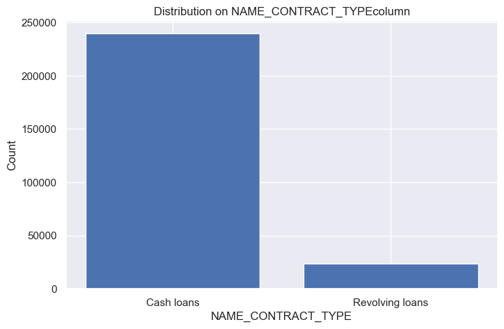

```python
plot_bar(df_application_train,'NAME_CONTRACT_TYPE')  ###(use label encoder)
```

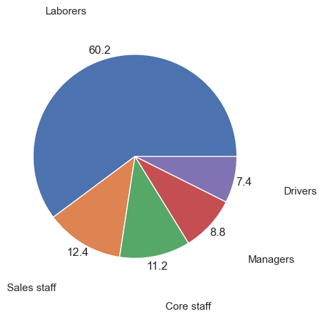

```python
df_application_train["OCCUPATION_TYPE"].value_counts().head(5).plot(kind='pie',autopct='%.1f',ylabel='', pctdistance=1.1, labeldistance=1.5)
```

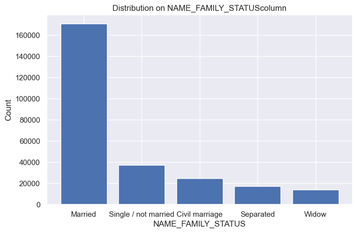

```python
plot_bar(df_application_train,'NAME_FAMILY_STATUS')
```

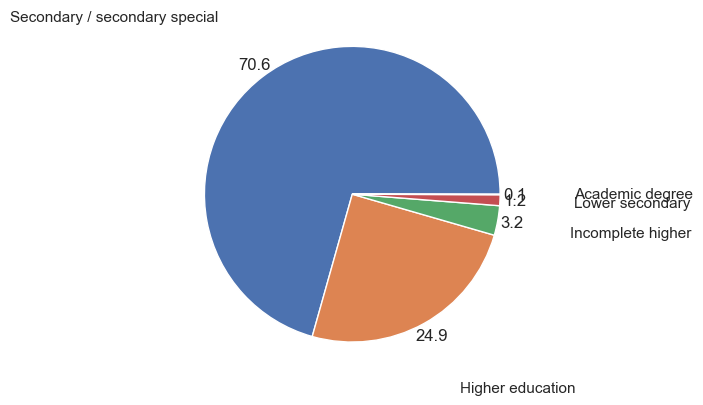

```python
df_application_train["NAME_EDUCATION_TYPE"].value_counts().plot(kind='pie',autopct='%.1f',ylabel='', pctdistance=1.1, labeldistance=1.5)
```

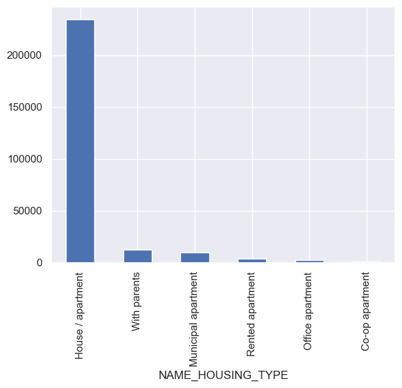

```python
df_application_train['NAME_HOUSING_TYPE'].value_counts().head(10).plot(kind='bar')
```

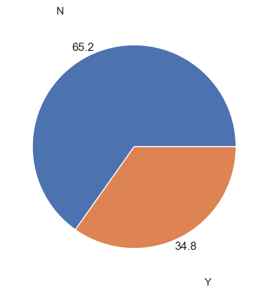

```python
df_application_train["FLAG_OWN_CAR"].value_counts().head(5).plot(kind='pie',autopct='%.1f',ylabel='', pctdistance=1.1, labeldistance=1.5)
```

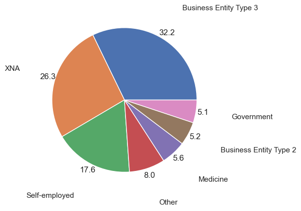

```python
df_application_train["ORGANIZATION_TYPE"].value_counts().head(7).plot(kind='pie',autopct='%.1f',ylabel='', pctdistance=1.1, labeldistance=1.5)
```

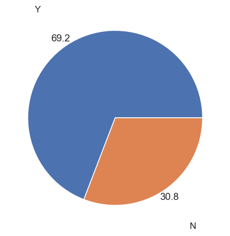

```python
df_application_train["FLAG_OWN_REALTY"].value_counts().plot(kind='pie',autopct='%.1f',ylabel='', pctdistance=1.1, labeldistance=1.5)
```

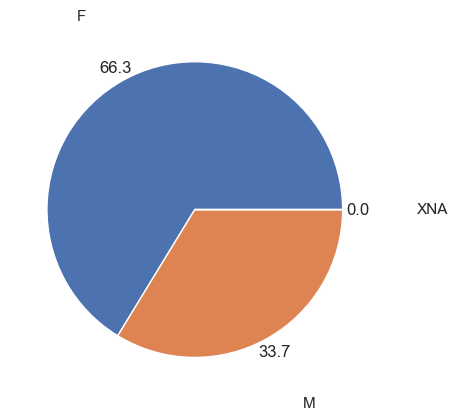

```python
df_application_train["CODE_GENDER"].value_counts().plot(kind='pie',autopct='%.1f',ylabel='', pctdistance=1.1, labeldistance=1.5)
```

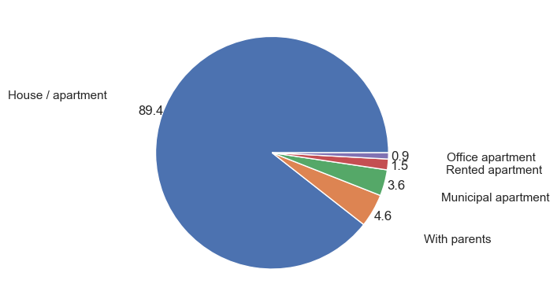

```python
df_application_train["NAME_HOUSING_TYPE"].value_counts().head(5).plot(kind='pie',autopct='%.1f',ylabel='', pctdistance=1.1, labeldistance=1.5)
```

### USE ENCODER

### LABEL ENCODER OR ORDINAL ENCODER

#### A label encoder is used for nominal data, while an ordinal encoder is used for ordinal data (follow an order e.g. cold,warm,hot).Ordinal encoder can introduce bias in the model ,so using only label encoder.

#### Other method can be one hot encoding ,that will increase the volume of a dataset.So we used it only for features that should not loose any values during removal of outliers

##### USING ONE HOT ENCODING FOR CONTRACT_TYPE,CODE_GENDER,FLAG_OWN_CAR,FLAG_OWN_REALTY,NAME_EDUCATION_TYPE

### ONE-HOT ENCODED COLUMNS

#### CONTRACT_TYPE,CODE_GENDER,FLAG_OWN_CAR,FLAG_OWN_REALTY, NAME_EDUCATION_TYPE

### LABEL ENCODED COLUMNS:

#### 'NAME_TYPE_SUITE', 'NAME_INCOME_TYPE','NAME_FAMILY_STATUS','NAME_HOUSING_TYPE', 'OCCUPATION_TYPE',

#### 'WEEKDAY_APPR_PROCESS_START', 'ORGANIZATION_TYPE'

```python
df_object.columns
```

```
Index(['NAME_CONTRACT_TYPE', 'CODE_GENDER', 'FLAG_OWN_CAR', 'FLAG_OWN_REALTY',
       'NAME_TYPE_SUITE', 'NAME_INCOME_TYPE', 'NAME_EDUCATION_TYPE',
       'NAME_FAMILY_STATUS', 'NAME_HOUSING_TYPE', 'OCCUPATION_TYPE',
       'WEEKDAY_APPR_PROCESS_START', 'ORGANIZATION_TYPE'],
      dtype='object')
```

```python
df_one_hot_encoded_columns=df_object[['NAME_CONTRACT_TYPE','CODE_GENDER','FLAG_OWN_CAR','FLAG_OWN_REALTY',
                                      'NAME_EDUCATION_TYPE']]
```

```python
df_label_encoded_columns=df_object[['NAME_TYPE_SUITE', 'NAME_INCOME_TYPE','NAME_FAMILY_STATUS',
                                    'NAME_HOUSING_TYPE', 'OCCUPATION_TYPE',
                                   'WEEKDAY_APPR_PROCESS_START', 'ORGANIZATION_TYPE']]
```

```python
import pandas as pd
from sklearn.preprocessing import LabelEncoder
```

```python
df_application_train_encoded= df_original_filtered.copy()
```

```python
df1=df_original_filtered.copy()
columns_to_encode= df_label_encoded_columns.columns
encoder = LabelEncoder()
# transform data
for column in columns_to_encode:
    df1[column] = encoder.fit_transform(df1[column])
```

```python
df_application_train_encoded= df1.copy()
```

```python
df_application_train_encoded.columns
```

```
Index(['SK_ID_CURR', 'NAME_CONTRACT_TYPE', 'CODE_GENDER', 'FLAG_OWN_CAR',
       'FLAG_OWN_REALTY', 'CNT_CHILDREN', 'AMT_INCOME_TOTAL', 'AMT_CREDIT',
       'AMT_ANNUITY', 'AMT_GOODS_PRICE', 'NAME_TYPE_SUITE', 'NAME_INCOME_TYPE',
       'NAME_EDUCATION_TYPE', 'NAME_FAMILY_STATUS', 'NAME_HOUSING_TYPE',
       'REGION_POPULATION_RELATIVE', 'DAYS_BIRTH', 'DAYS_EMPLOYED',
       'DAYS_REGISTRATION', 'DAYS_ID_PUBLISH', 'OCCUPATION_TYPE',
       'CNT_FAM_MEMBERS', 'REGION_RATING_CLIENT',
       'REGION_RATING_CLIENT_W_CITY', 'WEEKDAY_APPR_PROCESS_START',
       'HOUR_APPR_PROCESS_START', 'REG_REGION_NOT_LIVE_REGION',
       'REG_REGION_NOT_WORK_REGION', 'LIVE_REGION_NOT_WORK_REGION',
       'REG_CITY_NOT_LIVE_CITY', 'REG_CITY_NOT_WORK_CITY',
       'LIVE_CITY_NOT_WORK_CITY', 'ORGANIZATION_TYPE', 'EXT_SOURCE_2',
       'OBS_30_CNT_SOCIAL_CIRCLE', 'DEF_30_CNT_SOCIAL_CIRCLE',
       'OBS_60_CNT_SOCIAL_CIRCLE', 'DEF_60_CNT_SOCIAL_CIRCLE',
       'DAYS_LAST_PHONE_CHANGE', 'AMT_REQ_CREDIT_BUREAU_HOUR',
       'AMT_REQ_CREDIT_BUREAU_DAY', 'AMT_REQ_CREDIT_BUREAU_WEEK',
       'AMT_REQ_CREDIT_BUREAU_MON', 'AMT_REQ_CREDIT_BUREAU_QRT',
       'AMT_REQ_CREDIT_BUREAU_YEAR'],
      dtype='object')
```

### One hot encoded columns

```python
list(df_one_hot_encoded_columns.columns)
```

```
['NAME_CONTRACT_TYPE',
 'CODE_GENDER',
 'FLAG_OWN_CAR',
 'FLAG_OWN_REALTY',
 'NAME_EDUCATION_TYPE']
```

```python
df=df_application_train_encoded.copy()
columns_encoded=list(df_one_hot_encoded_columns.columns)
## Perform one-hot encoding
df_encoded = pd.get_dummies(df, columns=columns_encoded, prefix=columns_encoded )
```

```python
df_encoded.columns
```

```
Index(['SK_ID_CURR', 'CNT_CHILDREN', 'AMT_INCOME_TOTAL', 'AMT_CREDIT',
       'AMT_ANNUITY', 'AMT_GOODS_PRICE', 'NAME_TYPE_SUITE', 'NAME_INCOME_TYPE',
       'NAME_FAMILY_STATUS', 'NAME_HOUSING_TYPE', 'REGION_POPULATION_RELATIVE',
       'DAYS_BIRTH', 'DAYS_EMPLOYED', 'DAYS_REGISTRATION', 'DAYS_ID_PUBLISH',
       'OCCUPATION_TYPE', 'CNT_FAM_MEMBERS', 'REGION_RATING_CLIENT',
       'REGION_RATING_CLIENT_W_CITY', 'WEEKDAY_APPR_PROCESS_START',
       'HOUR_APPR_PROCESS_START', 'REG_REGION_NOT_LIVE_REGION',
       'REG_REGION_NOT_WORK_REGION', 'LIVE_REGION_NOT_WORK_REGION',
       'REG_CITY_NOT_LIVE_CITY', 'REG_CITY_NOT_WORK_CITY',
       'LIVE_CITY_NOT_WORK_CITY', 'ORGANIZATION_TYPE', 'EXT_SOURCE_2',
       'OBS_30_CNT_SOCIAL_CIRCLE', 'DEF_30_CNT_SOCIAL_CIRCLE',
       'OBS_60_CNT_SOCIAL_CIRCLE', 'DEF_60_CNT_SOCIAL_CIRCLE',
       'DAYS_LAST_PHONE_CHANGE', 'AMT_REQ_CREDIT_BUREAU_HOUR',
       'AMT_REQ_CREDIT_BUREAU_DAY', 'AMT_REQ_CREDIT_BUREAU_WEEK',
       'AMT_REQ_CREDIT_BUREAU_MON', 'AMT_REQ_CREDIT_BUREAU_QRT',
       'AMT_REQ_CREDIT_BUREAU_YEAR', 'NAME_CONTRACT_TYPE_Cash loans',
       'NAME_CONTRACT_TYPE_Revolving loans', 'CODE_GENDER_F', 'CODE_GENDER_M',
       'CODE_GENDER_XNA', 'FLAG_OWN_CAR_N', 'FLAG_OWN_CAR_Y',
       'FLAG_OWN_REALTY_N', 'FLAG_OWN_REALTY_Y',
       'NAME_EDUCATION_TYPE_Academic degree',
       'NAME_EDUCATION_TYPE_Higher education',
       'NAME_EDUCATION_TYPE_Incomplete higher',
       'NAME_EDUCATION_TYPE_Lower secondary',
       'NAME_EDUCATION_TYPE_Secondary / secondary special'],
      dtype='object')
```

```python
df_application_train_encoded =df_encoded
```

```python
df_application_train_encoded.shape
```

```
(263423, 54)
```

```python
df_application_train_encoded.head()
```

|  | SK_ID_CURR | CNT_CHILDREN | AMT_INCOME_TOTAL | AMT_CREDIT | AMT_ANNUITY | AMT_GOODS_PRICE | NAME_TYPE_SUITE | NAME_INCOME_TYPE | NAME_FAMILY_STATUS | NAME_HOUSING_TYPE | ... | CODE_GENDER_XNA | FLAG_OWN_CAR_N | FLAG_OWN_CAR_Y | FLAG_OWN_REALTY_N | FLAG_OWN_REALTY_Y | NAME_EDUCATION_TYPE_Academic degree | NAME_EDUCATION_TYPE_Higher education | NAME_EDUCATION_TYPE_Incomplete higher | NAME_EDUCATION_TYPE_Lower secondary | NAME_EDUCATION_TYPE_Secondary / secondary special |
| --- | --- | --- | --- | --- | --- | --- | --- | --- | --- | --- | --- | --- | --- | --- | --- | --- | --- | --- | --- | --- | --- |
| 0 | 100002 | 0 | 202500.0 | 406597.5 | 24700.5 | 351000.0 | 6 | 7 | 3 | 1 | ... | False | True | False | False | True | False | False | False | False | True |
| 1 | 100003 | 0 | 270000.0 | 1293502.5 | 35698.5 | 1129500.0 | 1 | 4 | 1 | 1 | ... | False | True | False | True | False | False | True | False | False | False |
| 2 | 100004 | 0 | 67500.0 | 135000.0 | 6750.0 | 135000.0 | 6 | 7 | 3 | 1 | ... | False | False | True | False | True | False | False | False | False | True |
| 4 | 100007 | 0 | 121500.0 | 513000.0 | 21865.5 | 513000.0 | 6 | 7 | 3 | 1 | ... | False | True | False | False | True | False | False | False | False | True |
| 5 | 100008 | 0 | 99000.0 | 490495.5 | 27517.5 | 454500.0 | 5 | 4 | 1 | 1 | ... | False | True | False | False | True | False | False | False | False | True |

5 rows × 54 columns

```python
df_application_train_encoded.info()
```

```
<class 'pandas.core.frame.DataFrame'>
Index: 263423 entries, 0 to 307510
Data columns (total 54 columns):
 #   Column                                             Non-Null Count   Dtype
---  ------                                             --------------   -----
 0   SK_ID_CURR                                         263423 non-null  int64
 1   CNT_CHILDREN                                       263423 non-null  int64
 2   AMT_INCOME_TOTAL                                   263423 non-null  float64
 3   AMT_CREDIT                                         263423 non-null  float64
 4   AMT_ANNUITY                                        263423 non-null  float64
 5   AMT_GOODS_PRICE                                    263423 non-null  float64
 6   NAME_TYPE_SUITE                                    263423 non-null  int32
 7   NAME_INCOME_TYPE                                   263423 non-null  int32
 8   NAME_FAMILY_STATUS                                 263423 non-null  int32
 9   NAME_HOUSING_TYPE                                  263423 non-null  int32
```

[output cut: 46 more lines]

### LABEL ENCODER USED

```python
df_object.columns
```

```
Index(['NAME_CONTRACT_TYPE', 'CODE_GENDER', 'FLAG_OWN_CAR', 'FLAG_OWN_REALTY',
       'NAME_TYPE_SUITE', 'NAME_INCOME_TYPE', 'NAME_EDUCATION_TYPE',
       'NAME_FAMILY_STATUS', 'NAME_HOUSING_TYPE', 'OCCUPATION_TYPE',
       'WEEKDAY_APPR_PROCESS_START', 'ORGANIZATION_TYPE'],
      dtype='object')
```

```python
df_application_train_encoded
```

|  | SK_ID_CURR | CNT_CHILDREN | AMT_INCOME_TOTAL | AMT_CREDIT | AMT_ANNUITY | AMT_GOODS_PRICE | NAME_TYPE_SUITE | NAME_INCOME_TYPE | NAME_FAMILY_STATUS | NAME_HOUSING_TYPE | ... | CODE_GENDER_XNA | FLAG_OWN_CAR_N | FLAG_OWN_CAR_Y | FLAG_OWN_REALTY_N | FLAG_OWN_REALTY_Y | NAME_EDUCATION_TYPE_Academic degree | NAME_EDUCATION_TYPE_Higher education | NAME_EDUCATION_TYPE_Incomplete higher | NAME_EDUCATION_TYPE_Lower secondary | NAME_EDUCATION_TYPE_Secondary / secondary special |
| --- | --- | --- | --- | --- | --- | --- | --- | --- | --- | --- | --- | --- | --- | --- | --- | --- | --- | --- | --- | --- | --- |
| 0 | 100002 | 0 | 202500.0 | 406597.5 | 24700.5 | 351000.0 | 6 | 7 | 3 | 1 | ... | False | True | False | False | True | False | False | False | False | True |
| 1 | 100003 | 0 | 270000.0 | 1293502.5 | 35698.5 | 1129500.0 | 1 | 4 | 1 | 1 | ... | False | True | False | True | False | False | True | False | False | False |
| 2 | 100004 | 0 | 67500.0 | 135000.0 | 6750.0 | 135000.0 | 6 | 7 | 3 | 1 | ... | False | False | True | False | True | False | False | False | False | True |
| 4 | 100007 | 0 | 121500.0 | 513000.0 | 21865.5 | 513000.0 | 6 | 7 | 3 | 1 | ... | False | True | False | False | True | False | False | False | False | True |
| 5 | 100008 | 0 | 99000.0 | 490495.5 | 27517.5 | 454500.0 | 5 | 4 | 1 | 1 | ... | False | True | False | False | True | False | False | False | False | True |
| ... | ... | ... | ... | ... | ... | ... | ... | ... | ... | ... | ... | ... | ... | ... | ... | ... | ... | ... | ... | ... | ... |
| 307503 | 456247 | 0 | 112500.0 | 345510.0 | 17770.5 | 247500.0 | 6 | 1 | 3 | 1 | ... | False | True | False | False | True | False | True | False | False | False |
| 307505 | 456249 | 0 | 112500.0 | 225000.0 | 22050.0 | 225000.0 | 6 | 3 | 3 | 1 | ... | False | True | False | False | True | False | False | False | False | True |
| 307508 | 456253 | 0 | 153000.0 | 677664.0 | 29979.0 | 585000.0 | 6 | 7 | 2 | 1 | ... | False | True | False | False | True | False | True | False | False | False |
| 307509 | 456254 | 0 | 171000.0 | 370107.0 | 20205.0 | 319500.0 | 6 | 1 | 1 | 1 | ... | False | True | False | False | True | False | False | False | False | True |
| 307510 | 456255 | 0 | 157500.0 | 675000.0 | 49117.5 | 675000.0 | 6 | 1 | 1 | 1 | ... | False | True | False | True | False | False | True | False | False | False |

263423 rows × 54 columns

## Checking Outliers in data

```
Outlier in CNT_CHILDREN column
```

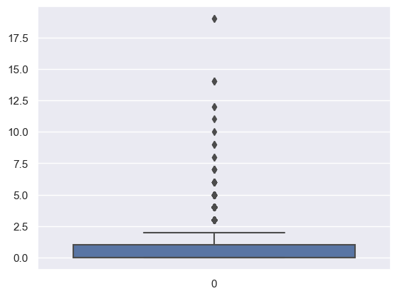

```
Outlier in AMT_INCOME_TOTAL column
```

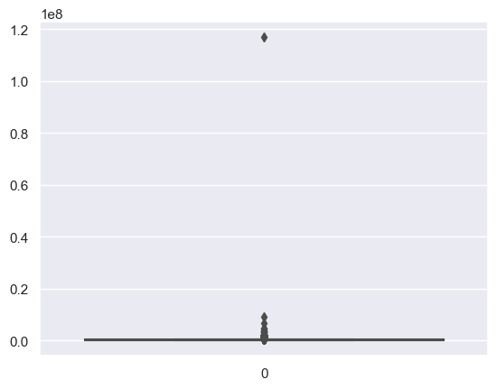

```
Outlier in AMT_CREDIT column
```

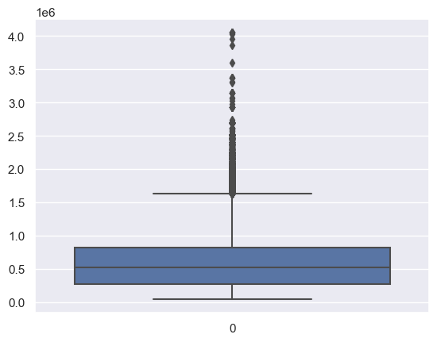

```
Outlier in AMT_ANNUITY column
```

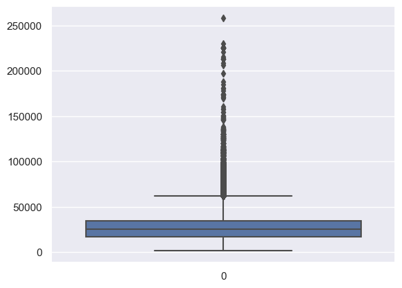

```
Outlier in AMT_GOODS_PRICE column
```

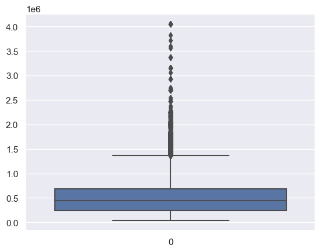

```
Outlier in NAME_TYPE_SUITE column
```

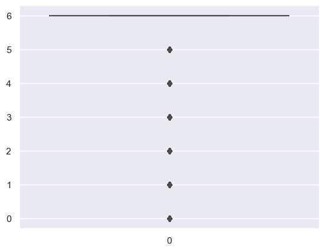

```
Outlier in NAME_INCOME_TYPE column
```

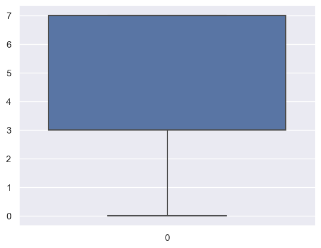

```
Outlier in NAME_FAMILY_STATUS column
```

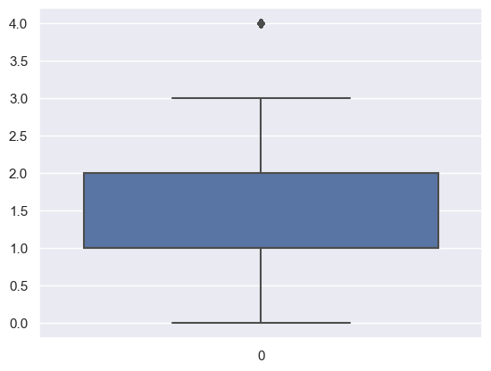

```
Outlier in NAME_HOUSING_TYPE column
```

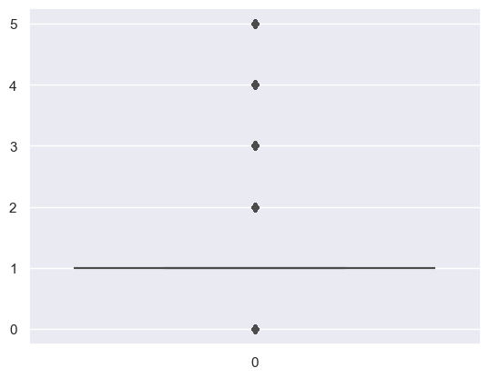

```
Outlier in REGION_POPULATION_RELATIVE column
```

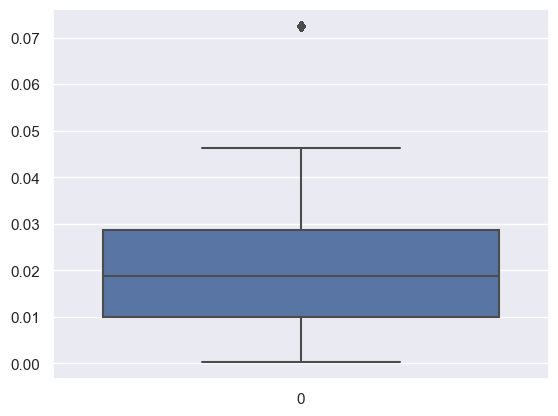

```
Outlier in DAYS_BIRTH column
```

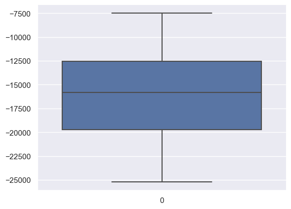

```
Outlier in DAYS_EMPLOYED column
```

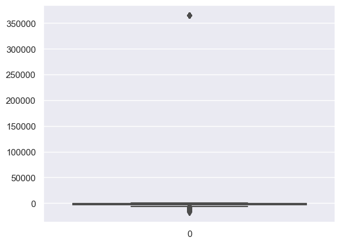

```
Outlier in DAYS_REGISTRATION column
```

[21 more figures not shown]

```python
outliers_chk(df_application_train_encoded)
```

```python
df_numeric = df_application_train_encoded.select_dtypes(exclude=['boolean'])# as booleans are not required
```

```python
df_numeric.columns
```

```
Index(['SK_ID_CURR', 'CNT_CHILDREN', 'AMT_INCOME_TOTAL', 'AMT_CREDIT',
       'AMT_ANNUITY', 'AMT_GOODS_PRICE', 'NAME_TYPE_SUITE', 'NAME_INCOME_TYPE',
       'NAME_FAMILY_STATUS', 'NAME_HOUSING_TYPE', 'REGION_POPULATION_RELATIVE',
       'DAYS_BIRTH', 'DAYS_EMPLOYED', 'DAYS_REGISTRATION', 'DAYS_ID_PUBLISH',
       'OCCUPATION_TYPE', 'CNT_FAM_MEMBERS', 'REGION_RATING_CLIENT',
       'REGION_RATING_CLIENT_W_CITY', 'WEEKDAY_APPR_PROCESS_START',
       'HOUR_APPR_PROCESS_START', 'REG_REGION_NOT_LIVE_REGION',
       'REG_REGION_NOT_WORK_REGION', 'LIVE_REGION_NOT_WORK_REGION',
       'REG_CITY_NOT_LIVE_CITY', 'REG_CITY_NOT_WORK_CITY',
       'LIVE_CITY_NOT_WORK_CITY', 'ORGANIZATION_TYPE', 'EXT_SOURCE_2',
       'OBS_30_CNT_SOCIAL_CIRCLE', 'DEF_30_CNT_SOCIAL_CIRCLE',
       'OBS_60_CNT_SOCIAL_CIRCLE', 'DEF_60_CNT_SOCIAL_CIRCLE',
       'DAYS_LAST_PHONE_CHANGE', 'AMT_REQ_CREDIT_BUREAU_HOUR',
       'AMT_REQ_CREDIT_BUREAU_DAY', 'AMT_REQ_CREDIT_BUREAU_WEEK',
       'AMT_REQ_CREDIT_BUREAU_MON', 'AMT_REQ_CREDIT_BUREAU_QRT',
       'AMT_REQ_CREDIT_BUREAU_YEAR'],
      dtype='object')
```

```python
df_application_train_encoded.head()
```

|  | SK_ID_CURR | CNT_CHILDREN | AMT_INCOME_TOTAL | AMT_CREDIT | AMT_ANNUITY | AMT_GOODS_PRICE | NAME_TYPE_SUITE | NAME_INCOME_TYPE | NAME_FAMILY_STATUS | NAME_HOUSING_TYPE | ... | CODE_GENDER_XNA | FLAG_OWN_CAR_N | FLAG_OWN_CAR_Y | FLAG_OWN_REALTY_N | FLAG_OWN_REALTY_Y | NAME_EDUCATION_TYPE_Academic degree | NAME_EDUCATION_TYPE_Higher education | NAME_EDUCATION_TYPE_Incomplete higher | NAME_EDUCATION_TYPE_Lower secondary | NAME_EDUCATION_TYPE_Secondary / secondary special |
| --- | --- | --- | --- | --- | --- | --- | --- | --- | --- | --- | --- | --- | --- | --- | --- | --- | --- | --- | --- | --- | --- |
| 0 | 100002 | 0 | 202500.0 | 406597.5 | 24700.5 | 351000.0 | 6 | 7 | 3 | 1 | ... | False | True | False | False | True | False | False | False | False | True |
| 1 | 100003 | 0 | 270000.0 | 1293502.5 | 35698.5 | 1129500.0 | 1 | 4 | 1 | 1 | ... | False | True | False | True | False | False | True | False | False | False |
| 2 | 100004 | 0 | 67500.0 | 135000.0 | 6750.0 | 135000.0 | 6 | 7 | 3 | 1 | ... | False | False | True | False | True | False | False | False | False | True |
| 4 | 100007 | 0 | 121500.0 | 513000.0 | 21865.5 | 513000.0 | 6 | 7 | 3 | 1 | ... | False | True | False | False | True | False | False | False | False | True |
| 5 | 100008 | 0 | 99000.0 | 490495.5 | 27517.5 | 454500.0 | 5 | 4 | 1 | 1 | ... | False | True | False | False | True | False | False | False | False | True |

5 rows × 54 columns

```python
df_application_train_encoded.describe()
```

|  | SK_ID_CURR | CNT_CHILDREN | AMT_INCOME_TOTAL | AMT_CREDIT | AMT_ANNUITY | AMT_GOODS_PRICE | NAME_TYPE_SUITE | NAME_INCOME_TYPE | NAME_FAMILY_STATUS | NAME_HOUSING_TYPE | ... | DEF_30_CNT_SOCIAL_CIRCLE | OBS_60_CNT_SOCIAL_CIRCLE | DEF_60_CNT_SOCIAL_CIRCLE | DAYS_LAST_PHONE_CHANGE | AMT_REQ_CREDIT_BUREAU_HOUR | AMT_REQ_CREDIT_BUREAU_DAY | AMT_REQ_CREDIT_BUREAU_WEEK | AMT_REQ_CREDIT_BUREAU_MON | AMT_REQ_CREDIT_BUREAU_QRT | AMT_REQ_CREDIT_BUREAU_YEAR |
| --- | --- | --- | --- | --- | --- | --- | --- | --- | --- | --- | --- | --- | --- | --- | --- | --- | --- | --- | --- | --- | --- |
| count | 263423.000000 | 263423.000000 | 2.634230e+05 | 2.634230e+05 | 263423.000000 | 2.634230e+05 | 263423.000000 | 263423.000000 | 263423.000000 | 263423.000000 | ... | 263423.000000 | 263423.000000 | 263423.000000 | 263423.000000 | 263423.000000 | 263423.000000 | 263423.000000 | 263423.000000 | 263423.000000 | 263423.000000 |
| mean | 278122.406115 | 0.422716 | 1.711735e+05 | 6.068547e+05 | 27214.157860 | 5.451637e+05 | 5.227588 | 4.670017 | 1.410222 | 1.277853 | ... | 0.143302 | 1.414937 | 0.099615 | -988.615045 | 0.006385 | 0.006981 | 0.034484 | 0.267782 | 0.266127 | 1.905904 |
| std | 102818.879287 | 0.725929 | 2.492428e+05 | 4.044311e+05 | 14379.858835 | 3.710472e+05 | 1.769261 | 2.540674 | 1.012623 | 0.930189 | ... | 0.446233 | 2.398673 | 0.361345 | 832.919043 | 0.083786 | 0.110358 | 0.204615 | 0.915330 | 0.795735 | 1.869645 |
| min | 100002.000000 | 0.000000 | 2.610000e+04 | 4.500000e+04 | 1615.500000 | 4.050000e+04 | 0.000000 | 0.000000 | 0.000000 | 0.000000 | ... | 0.000000 | 0.000000 | 0.000000 | -4185.000000 | 0.000000 | 0.000000 | 0.000000 | 0.000000 | 0.000000 | 0.000000 |
| 25% | 188975.500000 | 0.000000 | 1.125000e+05 | 2.730240e+05 | 16681.500000 | 2.385000e+05 | 6.000000 | 3.000000 | 1.000000 | 1.000000 | ... | 0.000000 | 0.000000 | 0.000000 | -1603.000000 | 0.000000 | 0.000000 | 0.000000 | 0.000000 | 0.000000 | 0.000000 |
| 50% | 278016.000000 | 0.000000 | 1.575000e+05 | 5.212800e+05 | 25033.500000 | 4.500000e+05 | 6.000000 | 7.000000 | 1.000000 | 1.000000 | ... | 0.000000 | 0.000000 | 0.000000 | -798.000000 | 0.000000 | 0.000000 | 0.000000 | 0.000000 | 0.000000 | 1.000000 |
| 75% | 367195.500000 | 1.000000 | 2.025000e+05 | 8.140410e+05 | 34780.500000 | 6.885000e+05 | 6.000000 | 7.000000 | 2.000000 | 1.000000 | ... | 0.000000 | 2.000000 | 0.000000 | -286.000000 | 0.000000 | 0.000000 | 0.000000 | 0.000000 | 0.000000 | 3.000000 |
| max | 456255.000000 | 19.000000 | 1.170000e+08 | 4.050000e+06 | 258025.500000 | 4.050000e+06 | 6.000000 | 7.000000 | 4.000000 | 5.000000 | ... | 34.000000 | 344.000000 | 24.000000 | 0.000000 | 4.000000 | 9.000000 | 8.000000 | 27.000000 | 261.000000 | 25.000000 |

8 rows × 40 columns

```python
def handling_outliers(df):
    Q1 = df.quantile(0.25)
    Q3 = df.quantile(0.75)
    IQR = Q3 - Q1
    whisker_width = 1.5
    lower_whisker = Q1 -(whisker_width*IQR)
    upper_whisker = Q3 + (whisker_width*IQR)
    df=np.where(df>upper_whisker,upper_whisker,np.where(df<lower_whisker,lower_whisker,df))

    return df
```

```python
df_app_train_before_handling_outliers= df_application_train_encoded.copy()
```

```python
df_app_train_before_handling_outliers.shape
```

```
(263423, 54)
```

```python
for name in df_numeric.columns:
    df_numeric[name] = handling_outliers(df_numeric[name])
```

```python
df_numeric.shape
```

```
(263423, 40)
```